# Practical Machine Learning: Course Project

Analysis of Weight Lifting Exercise Dataset

by_mcmillan03

## Introduction

The Weight Lifting dataset consists of sensor data recorded for six participants performing “one set of 10 repititions of the Unilateral Dumbbell Biceps Curl” using either correct (classe = A label) or incorrect (classe = B through E label) technique. The goal of this analysis is to train a model using only the raw sensor data as the input to predict what class of lifting technique is occuring. More information is available from the website here: http://groupware.les.inf.puc-rio.br/har (see the section on the Weight Lifting Exercise Dataset).

## Data Exploration and Cleaning

The dataset consists of 160 fields, including both raw sensor data and summary statistics of intervals of raw data for four accelerometers. These accelerometers measure the movement of the upper arm, forearm, belt and dumbbell. When the record has new_window=“yes”, it will also contain summary statistics (mean and variance) for an interval of the raw sensor data; otherwise the summary stats will be “NA”. Over 95% of the records (and all the final testing records) do not contain summary stats so these fields are omitted from the training set.

The record number field (“X”) was also removed it would have no predictive capability on the testing set for which the record numbers had been changed (reset to 1 through 20). Note that in training a random forest model using this field, the resulting accuracy is above 99.9% on the validation set. It is the most important variable with a “MeanDecreaseGini” that was order of magnitude higher then next most important variables.

All timestamp fields were removed (especially the factor variable) as it could be used to “place” the test records within the larger dataset and use the surrounding records’ “classe” label for prediction without any sensor information. Note that after the record number and timestamp variables, the most important variable (again according to a randomForest model) was the num_window variable, which is cruder way to “place”" the test records within the larger dataset to determine the “classe” as well. This variable was also removed.

After all these aforementioned fields are removed, the resulting dataset contains 19622 records with the following 53 fields:

```
##  [1] "roll_belt"            "pitch_belt"           "yaw_belt"
##  [4] "total_accel_belt"     "gyros_belt_x"         "gyros_belt_y"
##  [7] "gyros_belt_z"         "accel_belt_x"         "accel_belt_y"
## [10] "accel_belt_z"         "magnet_belt_x"        "magnet_belt_y"
## [13] "magnet_belt_z"        "roll_arm"             "pitch_arm"
## [16] "yaw_arm"              "total_accel_arm"      "gyros_arm_x"
## [19] "gyros_arm_y"          "gyros_arm_z"          "accel_arm_x"
## [22] "accel_arm_y"          "accel_arm_z"          "magnet_arm_x"
## [25] "magnet_arm_y"         "magnet_arm_z"         "roll_dumbbell"
## [28] "pitch_dumbbell"       "yaw_dumbbell"         "total_accel_dumbbell"
## [31] "gyros_dumbbell_x"     "gyros_dumbbell_y"     "gyros_dumbbell_z"
## [34] "accel_dumbbell_x"     "accel_dumbbell_y"     "accel_dumbbell_z"
## [37] "magnet_dumbbell_x"    "magnet_dumbbell_y"    "magnet_dumbbell_z"
## [40] "roll_forearm"         "pitch_forearm"        "yaw_forearm"
## [43] "total_accel_forearm"  "gyros_forearm_x"      "gyros_forearm_y"
## [46] "gyros_forearm_z"      "accel_forearm_x"      "accel_forearm_y"
## [49] "accel_forearm_z"      "magnet_forearm_x"     "magnet_forearm_y"
## [52] "magnet_forearm_z"     "classe"
```

These records are split into 30% training and 70% validation sets. Note that my final model using randomForests take a long time to train even with 30% yet they still perform very well.

## Random Forest Classification Using All Sensor Fields

In this work we perform the analysis by training a random forest classification model via the caret package and setting up the training parameters to perform 10-fold cross validation. Figure 1(a) shows that the of the model achieves perfect prediction (100% accuracy) on the training set. One expects the out-of-sample accuracy (accuracy of the model on data not in the training set) to be less, and indeed the Figure 1(b) shows the validation set accuracy to be 97.87%. Note that this model achieved perfect classification of the 20 records in the testing data for the programming submission portion of this exercise.

```
##           Reference
## Prediction    A    B    C    D    E
##          A 1674    0    0    0    0
##          B    0 1140    0    0    0
##          C    0    0 1027    0    0
##          D    0    0    0  965    0
##          E    0    0    0    0 1083
```

*(a) Perfomance on the training set.*

```
##           Reference
## Prediction    A    B    C    D    E
##          A 3886   69    0    0    0
##          B   17 2561   47    1    4
##          C    3   24 2332   44   12
##          D    0    2   16 2185   32
##          E    0    1    0   21 2476
```

*(b) Performance on the validation set.*

*Figure 1. Performance of the random forest model against the (a) training set showing 100% accuracy, and (b) validation set showning 97.87% accuracy.*

## Reduced Dataset

Training the random forest model on all the sensor values took a long time, so I decided to use variable importance to reduce the set of features further. The following figure shows what the random forest algorithm considers the 30 most important sensor variables (most important at the top):

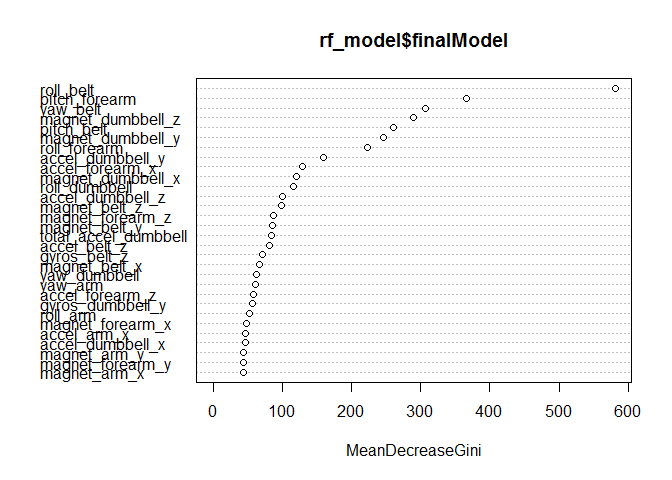

*Figure 2. Variable importance computed when training the random forest model.*

From this, the 17 most important variables are extracted and used to train a random forest model and a generalized boosted regression model (GBM) for comparison.

#### Random Forest Model (Reduced Dataset)

```
##           Reference
## Prediction    A    B    C    D    E
##          A 3881   72    3    4    1
##          B   21 2534   57    1   19
##          C    2   41 2298   64    9
##          D    2    6   37 2162   22
##          E    0    4    0   20 2473
```

*Figure 3. Perfomance on the validation data of the random forest model trained from a reduced set of features (note that it achieved perfect accuracy on the training set).*

#### Generalized Boosted Regression Model (Reduced Dataset)

In this section, a GBM model (distribution = “multinomial”) is trained on the reduced dataset (with 17 features) for comparison with the random forest model. As shown in Figure 4, the training set accuracy for this model the training is 96.98%. The out of sample accuracy using the validation set still very good at 94.26%.

```
##           Reference
## Prediction    A    B    C    D    E
##          A 1647   21    1    1    0
##          B   11 1085   27    4    7
##          C   12   27  981   20   10
##          D    3    5   16  940    8
##          E    1    2    2    0 1058
```

*(a) training set*

```
##           Reference
## Prediction    A    B    C    D    E
##          A 3788  108    5    5    7
##          B   65 2423  121    8   50
##          C   32   90 2197   89   31
##          D   18   14   68 2138   37
##          E    3   22    4   11 2399
```

*(b) validation set*

*Figure 4. Confusion matrix for GBM model using a reduced set of features.*

## Conclusion

Both the random forest and GBM models are both very accurate at determining the “classe” of a given set of raw sensor values. In fact, by using the random forest’s computation regarding variable importance, a model with one third of the original features is still able to exceed 97% and 94% out-of-sample accuracy for random forest and GBM (multinomial) models, respectively.